# Redes Neuronales Artificiales - Ejercicio 2

Maria Lucia Guastoni

13/3/2021

# 1 Data loading and analysis

El dataset que se analizará contiene información relativa a un estudio realizado entre 1958 y 1970 en el Billings Hospital de la Universidad de Chicago.

Se trata de 306 observaciones correspondientes a pacientes que atravesaron una cirgugía de cáncer de mama.

Para comenzar con el ánalisis, se cargan los datos:

```
  Age_of_patient_at_time_of_operation Patients_year_of_operation
1                                  30                         64
2                                  30                         62
3                                  30                         65
4                                  31                         59
5                                  31                         65
6                                  33                         58
  Number_of_positive_axillary_nodes_detected Survival_status
1                                          1               1
2                                          3               1
3                                          0               1
4                                          2               1
5                                          4               1
6                                         10               1
```

El dataset contiene cuatro variables, las primeras tres numéricas y la última binaria:

1. `Age_of_patient_at_time_of_operation`: edad, en año cumplidos, del paciente en el momento en que fue operado
2. `Patients_year_of_operation`: año del 1900 en que el paciente fue operado
3. `Number_of_positive_axillary_nodes_detected`: número de nodos detectados
4. `Survival_status`: 1 si el paciente sobrevivó 5 años o más, 2 si el paciente murió dentro de los 5 años siguientes a la operación.

A continuación se presentan estadísticos resúmen de las variables mencionadas, pero antes se le cambiará el nombre a las variables para facilitar el trabajo:

```
      edad            año            nodos            status
 Min.   :30.00   Min.   :58.00   Min.   : 0.000   Min.   :1.000
 1st Qu.:44.00   1st Qu.:60.00   1st Qu.: 0.000   1st Qu.:1.000
 Median :52.00   Median :63.00   Median : 1.000   Median :1.000
 Mean   :52.46   Mean   :62.85   Mean   : 4.026   Mean   :1.265
 3rd Qu.:60.75   3rd Qu.:65.75   3rd Qu.: 4.000   3rd Qu.:2.000
 Max.   :83.00   Max.   :69.00   Max.   :52.000   Max.   :2.000
```

Parece que podría haber valores extremos en la cantidad de nodos. Se examinan los valores de dicha variable:

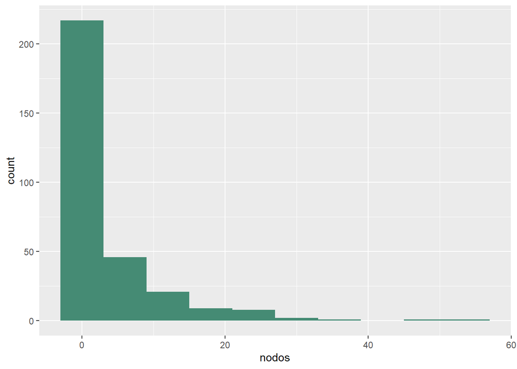

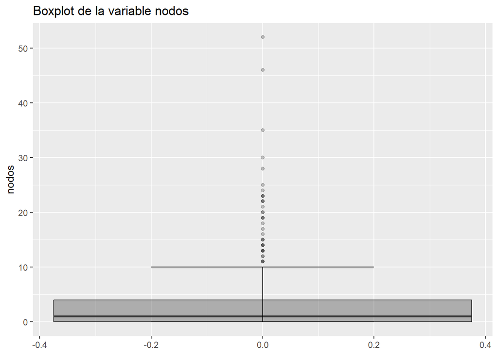

Número de casos según cantidad de nodos

| Nodos | Frecuencia |
| --- | --- |
| 0 | 136 |
| 1 | 41 |
| 2 | 20 |
| 3 | 20 |
| 4 | 13 |
| 5 | 6 |
| 6 | 7 |
| 7 | 7 |
| 8 | 7 |
| 9 | 6 |
| 10 | 3 |
| 11 | 4 |
| 12 | 2 |
| 13 | 5 |
| 14 | 4 |
| 15 | 3 |
| 16 | 1 |
| 17 | 1 |
| 18 | 1 |
| 19 | 3 |
| 20 | 2 |
| 21 | 1 |
| 22 | 3 |
| 23 | 3 |
| 24 | 1 |
| 25 | 1 |
| 28 | 1 |
| 30 | 1 |
| 35 | 1 |
| 46 | 1 |
| 52 | 1 |

Efectivamente, como puede verse en el boxplot, una cantidad superior a 10 nodos puede considerarse como oulier. Esto será tenido en cuenta a la hora de entrenar la red neuronal.

Luego se desea comprobar si existen valores nulos:

```
  edad    año  nodos status
     0      0      0      0
```

Y finalmente, se evalúa el nivel de correlación entre cada una de las variables:

```
              edad          año        nodos      status
edad    1.00000000  0.089529446 -0.063176102  0.06795032
año     0.08952945  1.000000000 -0.003764474 -0.00476818
nodos  -0.06317610 -0.003764474  1.000000000  0.28676757
status  0.06795032 -0.004768180  0.286767567  1.00000000
```

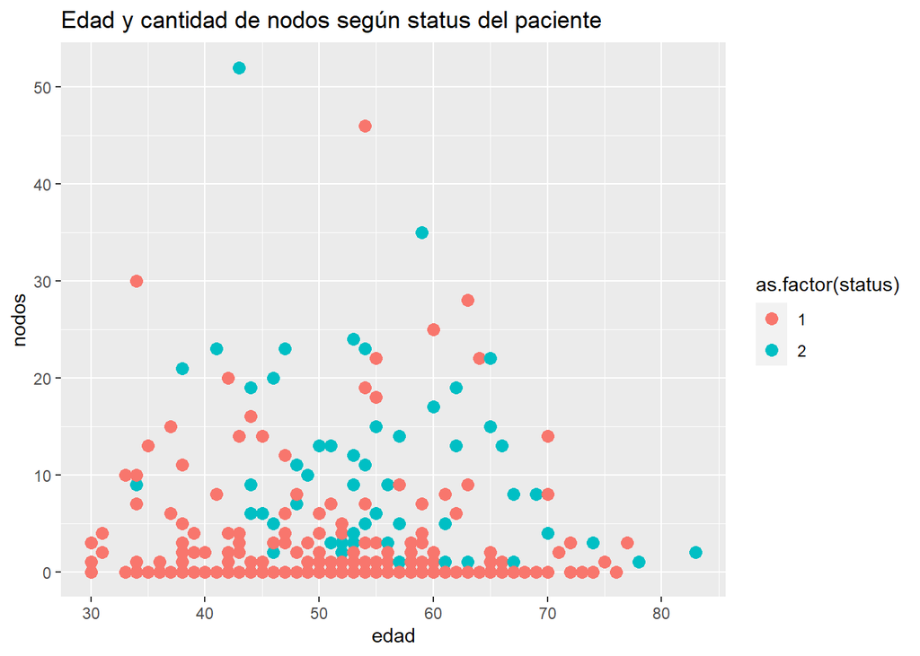

La matriz de correlaciones no muestra fuerte relaciones entre las variables; la de mayor valor es la que hay entre cantidad de nodos y status, que no llega al 0.3.

# 2 Data preprocessing

Una vez que se han analizando los datos, se procede a prepararlos para luego entrenar la red neuronal.

Se desea tomar en consideración diferentes variaciones en los datos, a saber:

- datos normalizados
- datos estanzarizados
- datos sin outliers

Por lo tanto, se realizarán las transformaciones necesarias, y al final se separaran los datos en train y test.

## 2.1 Datos sin outliers

Como se ha visto anteriormente, a partir de 10 nodos se está en presencia de outliers. Sin embargo, se flexibilizará la condición para no perder tantos datos: se eliminarán los 22 casos cuya cantidad de nodos es superior a 15, los cuales representan 7.2% del total de observaciones del dataset.

```
[1] 7.189542
```

## 2.2 Datos normalizados

Se normalizarán los datos, tanto el dataset original como el que no tiene outliers:

## 2.3 Datos estandarizados

Por lo tanto, hasta el momento, tenemos los siguientes datasets:

- datos originales - df
- datos originales sin outliers - df_out
- datos normalizados - df_n
- datos normalizados sin outliers - df_out_n
- datos estandarizados: df_s
- datos estandarizados sin outliers: df_out_s

## 2.4 Train test split

Se separarán los datos que se usarán para entrenamiento de aquellos para evaluar el modelo. Esto se aplicará a todos los datasets definidos en el apartado anterior, excepto para los dos datasets con los datos originales, puesto que los rangos de valores de cada una de las variables son diferentes.

```
        0         1
0.7347826 0.2652174
```

```
        0         1
0.7746479 0.2253521
```

```
        0         1
0.7368421 0.2631579
```

```
        0         1
0.7042254 0.2957746
```

Dado que se evaluarán 4 datasets con 2 tamaños distintos (230 observaciones para los dos datasets que incluyen los outliers y 213 observaciones para los dos datasets que no incluyen los outliers), se realizan dos asignaciones de indices, uno para cada tipo de dataset.

La partición que se realiza será luego introducida en la función `trainControl`.

# 3 Aplicación de diversos modelos

A continuación se aplicarán diversos modelos, según los diferentes valores que los hiperparametros de una red neuronal pueden tomar.

Para llevar a cabo esta tarea, después de haber investigado diferentes paquetes y maneras de hacerlo (como por ejemplo `AMORE` y `neuralnet`), se ha optado por el paquete `caret`. El motivo es que este último permite utilizar un grid para realizar el tuning de los parámetros, logrando probar múltiples combinaciones de parámetros de forma eficiente.

`nnet` es el modelo particular de red neuronal que se ha escogido. Este consiste en una red con una sola capa oculta. Se considera que esta estructura es apropiada para el conjunto de datos que se está analizando.

Los hiperparametros que se analizarán son:

- decay factor: se evaluarán los siguientes valores: 0.001, 0.01, 0.1, 0.3 y 0.5. Para ello, se utiliza el parámetro `decay` de la función `expand.grid`.
- cantidad de neuronas: se configura a través del parámetro `size` de la función `expand.grid`. Los valores a tener en cuenta son: 1, 2 y 3 neuronas.
- pesos iniciales: se fija el valor máximo que los mismos pueden tomar, y luego se introduce a través del parámetro MaxNWts de la función `train` de `caret`.
- número de epochs (`maxit`): lamentablemente este parámetro no puede introducirse en el grid, por lo que se aplicará manualmente, es decir, se realizará un modelo para cada uno de los tres valores que se tomará esta variable: 500, 800 y 1000 iteraciones.
- preparación de los datos: esta posibilidad tampoco esta contemplada como parámetro a tunear en el grid, por tanto, también se aplicará manualmente. Se considerarán los datos normalizados y estandarizados, con y sin outliers. Cabe recordar, tal como se mencionó previamente, que los datos originales (es decir, sin estandarizar ni normalizar) no se utilizarán como input de la red neuronal, dado el diferente rango de valores que poseen cada una de las features del dataset.
- función de activación: entre las desventajas de `nnet` se cuenta con que no se puede elegir la función de activación a implementar. La función que se utiliza es la sigmoidea logística.

## 3.1 Datos normalizados

### 3.1.1 Datos normalizados con outliers

#### 3.1.1.1 número de iteraciones = 500

```
Neural Network

230 samples
  3 predictor
  2 classes: '0', '1'

No pre-processing
Resampling: Cross-Validated (10 fold)
Summary of sample sizes: 184, 184, 184, 184, 184, 184, ...
Resampling results across tuning parameters:

  size  decay  Accuracy   Kappa
  1     0.001  0.7318841  0.219735894
  1     0.010  0.7391304  0.241228603
  1     0.100  0.7391304  0.181197480
  1     0.300  0.7275362  0.061328585
  1     0.500  0.7231884  0.009876543
  2     0.001  0.7188406  0.205311345
  2     0.010  0.7347826  0.204920405
  2     0.100  0.7405797  0.184097305
  2     0.300  0.7260870  0.061948654
  2     0.500  0.7246377  0.018750000
  3     0.001  0.7057971  0.118585932
  3     0.010  0.7405797  0.245202757
  3     0.100  0.7391304  0.176901178
  3     0.300  0.7275362  0.064670205
  3     0.500  0.7275362  0.032314857

Accuracy was used to select the optimal model using the largest value.
The final values used for the model were size = 2 and decay = 0.1.
```

#### 3.1.1.2 número de iteraciones = 800

```
Neural Network

230 samples
  3 predictor
  2 classes: '0', '1'

No pre-processing
Resampling: Cross-Validated (10 fold)
Summary of sample sizes: 184, 184, 184, 184, 184, 184, ...
Resampling results across tuning parameters:

  size  decay  Accuracy   Kappa
  1     0.001  0.7318841  0.219735894
  1     0.010  0.7391304  0.241228603
  1     0.100  0.7391304  0.181197480
  1     0.300  0.7275362  0.061328585
  1     0.500  0.7231884  0.009876543
  2     0.001  0.7188406  0.205311345
  2     0.010  0.7347826  0.204920405
  2     0.100  0.7405797  0.184097305
  2     0.300  0.7260870  0.061948654
  2     0.500  0.7246377  0.018750000
  3     0.001  0.7057971  0.118585932
  3     0.010  0.7405797  0.245202757
  3     0.100  0.7391304  0.176901178
  3     0.300  0.7275362  0.064670205
  3     0.500  0.7275362  0.032314857

Accuracy was used to select the optimal model using the largest value.
The final values used for the model were size = 2 and decay = 0.1.
```

#### 3.1.1.3 número de iteraciones = 1000

```
Neural Network

230 samples
  3 predictor
  2 classes: '0', '1'

No pre-processing
Resampling: Cross-Validated (10 fold)
Summary of sample sizes: 184, 184, 184, 184, 184, 184, ...
Resampling results across tuning parameters:

  size  decay  Accuracy   Kappa
  1     0.001  0.7318841  0.219735894
  1     0.010  0.7391304  0.241228603
  1     0.100  0.7391304  0.181197480
  1     0.300  0.7275362  0.061328585
  1     0.500  0.7231884  0.009876543
  2     0.001  0.7188406  0.205311345
  2     0.010  0.7347826  0.204920405
  2     0.100  0.7405797  0.184097305
  2     0.300  0.7260870  0.061948654
  2     0.500  0.7246377  0.018750000
  3     0.001  0.7057971  0.118585932
  3     0.010  0.7405797  0.245202757
  3     0.100  0.7391304  0.176901178
  3     0.300  0.7275362  0.064670205
  3     0.500  0.7275362  0.032314857

Accuracy was used to select the optimal model using the largest value.
The final values used for the model were size = 2 and decay = 0.1.
```

### 3.1.2 Datos normalizados sin outliers

#### 3.1.2.1 número de iteraciones = 500

```
Neural Network

213 samples
  3 predictor
  2 classes: '0', '1'

No pre-processing
Resampling: Cross-Validated (10 fold)
Summary of sample sizes: 170, 170, 170, 170, 170, 170, ...
Resampling results across tuning parameters:

  size  decay  Accuracy   Kappa
  1     0.001  0.8000000  0.32493982
  1     0.010  0.7953488  0.26464140
  1     0.100  0.8248062  0.28784222
  1     0.300  0.8232558  0.21095427
  1     0.500  0.8077519  0.06507265
  2     0.001  0.7937984  0.26948854
  2     0.010  0.7984496  0.26143940
  2     0.100  0.8232558  0.28507409
  2     0.300  0.8232558  0.21828633
  2     0.500  0.8077519  0.07141020
  3     0.001  0.7860465  0.26200888
  3     0.010  0.7736434  0.22061775
  3     0.100  0.8217054  0.28129689
  3     0.300  0.8217054  0.20374088
  3     0.500  0.8108527  0.11454410

Accuracy was used to select the optimal model using the largest value.
The final values used for the model were size = 1 and decay = 0.1.
```

#### 3.1.2.2 número de iteraciones = 800

```
Neural Network

213 samples
  3 predictor
  2 classes: '0', '1'

No pre-processing
Resampling: Cross-Validated (10 fold)
Summary of sample sizes: 170, 170, 170, 170, 170, 170, ...
Resampling results across tuning parameters:

  size  decay  Accuracy   Kappa
  1     0.001  0.8000000  0.32493982
  1     0.010  0.7953488  0.26464140
  1     0.100  0.8248062  0.28784222
  1     0.300  0.8232558  0.21095427
  1     0.500  0.8077519  0.06507265
  2     0.001  0.7937984  0.26948854
  2     0.010  0.7984496  0.26143940
  2     0.100  0.8232558  0.28507409
  2     0.300  0.8232558  0.21828633
  2     0.500  0.8077519  0.07141020
  3     0.001  0.7860465  0.26200888
  3     0.010  0.7736434  0.22061775
  3     0.100  0.8217054  0.28129689
  3     0.300  0.8217054  0.20374088
  3     0.500  0.8108527  0.11454410

Accuracy was used to select the optimal model using the largest value.
The final values used for the model were size = 1 and decay = 0.1.
```

#### 3.1.2.3 número de iteraciones = 1000

```
Neural Network

213 samples
  3 predictor
  2 classes: '0', '1'

No pre-processing
Resampling: Cross-Validated (10 fold)
Summary of sample sizes: 170, 170, 170, 170, 170, 170, ...
Resampling results across tuning parameters:

  size  decay  Accuracy   Kappa
  1     0.001  0.8000000  0.32493982
  1     0.010  0.7953488  0.26464140
  1     0.100  0.8248062  0.28784222
  1     0.300  0.8232558  0.21095427
  1     0.500  0.8077519  0.06507265
  2     0.001  0.7937984  0.26948854
  2     0.010  0.7984496  0.26143940
  2     0.100  0.8232558  0.28507409
  2     0.300  0.8232558  0.21828633
  2     0.500  0.8077519  0.07141020
  3     0.001  0.7860465  0.26200888
  3     0.010  0.7736434  0.22061775
  3     0.100  0.8217054  0.28129689
  3     0.300  0.8217054  0.20374088
  3     0.500  0.8108527  0.11454410

Accuracy was used to select the optimal model using the largest value.
The final values used for the model were size = 1 and decay = 0.1.
```

## 3.2 Datos estandarizados

### 3.2.1 Datos estandarizados con outliers

#### 3.2.1.1 número de iteraciones = 500

```
Neural Network

230 samples
  3 predictor
  2 classes: '0', '1'

No pre-processing
Resampling: Cross-Validated (10 fold)
Summary of sample sizes: 184, 184, 184, 184, 184, 184, ...
Resampling results across tuning parameters:

  size  decay  Accuracy   Kappa
  1     0.001  0.7101449  0.1055891
  1     0.010  0.7217391  0.1954598
  1     0.100  0.7405797  0.2564111
  1     0.300  0.7362319  0.1942966
  1     0.500  0.7318841  0.1442891
  2     0.001  0.7289855  0.2180282
  2     0.010  0.7318841  0.2273131
  2     0.100  0.7362319  0.2133390
  2     0.300  0.7347826  0.1832946
  2     0.500  0.7275362  0.1467501
  3     0.001  0.6927536  0.1463546
  3     0.010  0.7057971  0.1594975
  3     0.100  0.7347826  0.2102440
  3     0.300  0.7347826  0.1856843
  3     0.500  0.7347826  0.1717083

Accuracy was used to select the optimal model using the largest value.
The final values used for the model were size = 1 and decay = 0.1.
```

#### 3.2.1.2 número de iteraciones = 800

```
Neural Network

230 samples
  3 predictor
  2 classes: '0', '1'

No pre-processing
Resampling: Cross-Validated (10 fold)
Summary of sample sizes: 184, 184, 184, 184, 184, 184, ...
Resampling results across tuning parameters:

  size  decay  Accuracy   Kappa
  1     0.001  0.7101449  0.1055891
  1     0.010  0.7217391  0.1954598
  1     0.100  0.7405797  0.2564111
  1     0.300  0.7362319  0.1942966
  1     0.500  0.7318841  0.1442891
  2     0.001  0.7289855  0.2180282
  2     0.010  0.7318841  0.2273131
  2     0.100  0.7362319  0.2133390
  2     0.300  0.7347826  0.1832946
  2     0.500  0.7275362  0.1467501
  3     0.001  0.6927536  0.1463546
  3     0.010  0.7057971  0.1594975
  3     0.100  0.7347826  0.2102440
  3     0.300  0.7347826  0.1856843
  3     0.500  0.7347826  0.1717083

Accuracy was used to select the optimal model using the largest value.
The final values used for the model were size = 1 and decay = 0.1.
```

#### 3.2.1.3 número de iteraciones = 1000

```
Neural Network

230 samples
  3 predictor
  2 classes: '0', '1'

No pre-processing
Resampling: Cross-Validated (10 fold)
Summary of sample sizes: 184, 184, 184, 184, 184, 184, ...
Resampling results across tuning parameters:

  size  decay  Accuracy   Kappa
  1     0.001  0.7101449  0.1055891
  1     0.010  0.7217391  0.1954598
  1     0.100  0.7405797  0.2564111
  1     0.300  0.7362319  0.1942966
  1     0.500  0.7318841  0.1442891
  2     0.001  0.7289855  0.2180282
  2     0.010  0.7318841  0.2273131
  2     0.100  0.7362319  0.2133390
  2     0.300  0.7347826  0.1832946
  2     0.500  0.7275362  0.1467501
  3     0.001  0.6927536  0.1463546
  3     0.010  0.7057971  0.1594975
  3     0.100  0.7347826  0.2102440
  3     0.300  0.7347826  0.1856843
  3     0.500  0.7347826  0.1717083

Accuracy was used to select the optimal model using the largest value.
The final values used for the model were size = 1 and decay = 0.1.
```

### 3.2.2 Datose estandarizados sin outliers

#### 3.2.2.1 número de iteraciones = 500

```
Neural Network

213 samples
  3 predictor
  2 classes: '0', '1'

No pre-processing
Resampling: Cross-Validated (10 fold)
Summary of sample sizes: 170, 170, 170, 170, 170, 170, ...
Resampling results across tuning parameters:

  size  decay  Accuracy   Kappa
  1     0.001  0.7674419  0.2395415
  1     0.010  0.7875969  0.3045900
  1     0.100  0.8046512  0.2567042
  1     0.300  0.8325581  0.3040570
  1     0.500  0.8077519  0.1052430
  2     0.001  0.7705426  0.2290072
  2     0.010  0.7782946  0.2224166
  2     0.100  0.8062016  0.2274508
  2     0.300  0.8217054  0.2667546
  2     0.500  0.8155039  0.1663319
  3     0.001  0.7798450  0.2760176
  3     0.010  0.7736434  0.2496566
  3     0.100  0.8108527  0.2709913
  3     0.300  0.8170543  0.2565648
  3     0.500  0.8217054  0.2038255

Accuracy was used to select the optimal model using the largest value.
The final values used for the model were size = 1 and decay = 0.3.
```

#### 3.2.2.2 número de iteraciones = 800

```
Neural Network

213 samples
  3 predictor
  2 classes: '0', '1'

No pre-processing
Resampling: Cross-Validated (10 fold)
Summary of sample sizes: 170, 170, 170, 170, 170, 170, ...
Resampling results across tuning parameters:

  size  decay  Accuracy   Kappa
  1     0.001  0.7674419  0.2395415
  1     0.010  0.7875969  0.3045900
  1     0.100  0.8046512  0.2567042
  1     0.300  0.8325581  0.3040570
  1     0.500  0.8077519  0.1052430
  2     0.001  0.7705426  0.2290072
  2     0.010  0.7782946  0.2224166
  2     0.100  0.8062016  0.2274508
  2     0.300  0.8217054  0.2667546
  2     0.500  0.8155039  0.1663319
  3     0.001  0.7798450  0.2760176
  3     0.010  0.7736434  0.2496566
  3     0.100  0.8108527  0.2709913
  3     0.300  0.8170543  0.2565648
  3     0.500  0.8217054  0.2038255

Accuracy was used to select the optimal model using the largest value.
The final values used for the model were size = 1 and decay = 0.3.
```

#### 3.2.2.3 número de iteraciones = 1000

```
Neural Network

213 samples
  3 predictor
  2 classes: '0', '1'

No pre-processing
Resampling: Cross-Validated (10 fold)
Summary of sample sizes: 170, 170, 170, 170, 170, 170, ...
Resampling results across tuning parameters:

  size  decay  Accuracy   Kappa
  1     0.001  0.7674419  0.2395415
  1     0.010  0.7875969  0.3045900
  1     0.100  0.8046512  0.2567042
  1     0.300  0.8325581  0.3040570
  1     0.500  0.8077519  0.1052430
  2     0.001  0.7705426  0.2290072
  2     0.010  0.7782946  0.2224166
  2     0.100  0.8062016  0.2274508
  2     0.300  0.8217054  0.2667546
  2     0.500  0.8155039  0.1663319
  3     0.001  0.7798450  0.2760176
  3     0.010  0.7736434  0.2496566
  3     0.100  0.8108527  0.2709913
  3     0.300  0.8170543  0.2565648
  3     0.500  0.8217054  0.2038255

Accuracy was used to select the optimal model using the largest value.
The final values used for the model were size = 1 and decay = 0.3.
```

# 4 Comparación de modelos

#### 4.0.0.1 Dataset estandarizado, sin outliers y 50 iteraciones:

```
  size decay  Accuracy    Kappa AccuracySD   KappaSD
4    1   0.3 0.8325581 0.304057  0.0550333 0.1625609
```

#### 4.0.0.2 Dataset estandarizado, sin outliers y 10 iteraciones:

```
   size decay  Accuracy     Kappa AccuracySD   KappaSD
14    3   0.3 0.8263566 0.2629122 0.05337028 0.1245346
```

# 5 Conclusión

Por lo tanto, como modelo final se elige el modelo con los datos estandarizados, sin outliers, con una capa con una neurona, un decay factor de 0.3, 50 iteraciones y los siguientes pesos iniciales:

```
     b->h1     i1->h1     i2->h1     i3->h1       b->o      h1->o
 1.4782639 -1.3911959  0.8572220 -1.4501741  0.4156588 -2.5560410
```

```
Confusion Matrix and Statistics

          Reference
Prediction  0  1
         0 50 19
         1  0  2

               Accuracy : 0.7324
                 95% CI : (0.6141, 0.8306)
    No Information Rate : 0.7042
    P-Value [Acc > NIR] : 0.354

                  Kappa : 0.1291

 Mcnemar's Test P-Value : 3.636e-05

            Sensitivity : 1.00000
            Specificity : 0.09524
         Pos Pred Value : 0.72464
         Neg Pred Value : 1.00000
             Prevalence : 0.70423
         Detection Rate : 0.70423
   Detection Prevalence : 0.97183
      Balanced Accuracy : 0.54762

       'Positive' Class : 0
```

El modelo final evaluado en test tiene un Accuracy de 0.7324.

De la matriz de confusión puede verse que el modelo sólo predice 2 de los 21 casos positivos (status = 1) del set de testeo, y clasifica correctamente la totalidad de los casos negativos (status = 0).

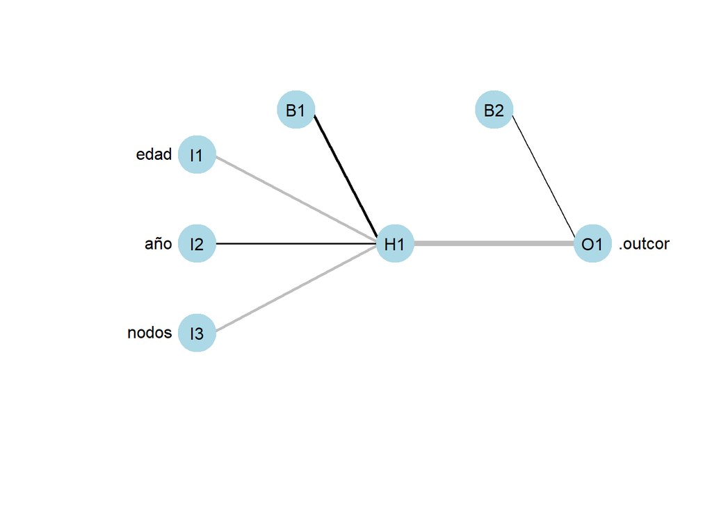

# 6 Pruebas extra con `neuralnet`

Dado que la función `nnet` posee ciertas limitaciones que neuralnet no, se harán algunas pruebas mínimas para investigar si es posible mejorar el accuracy logrado hasta el momento.

Se realizarán combiaciones de los siguientes parámetros:

- funciones de activación: logística y tangencial
- número de capas ocultas: se analizará una estructura de 2 capas
- número de neuronas por capa: 1 o 2
- learning rate: de 0.3

Se utilizará el set de datos que dio mejores resultados en el análisis anterior, es decir, el set de datos estandarizado y sin outliers.

Antes de aplicar los modelos, para poder utilizar la función tangencial, es necesario que las labels sean -1 o 1:

## 6.1 Función de activación logística

### 6.1.1 Una capa con una neurona

```
Confusion Matrix and Statistics

          Reference
Prediction  0  1
         0 44 19
         1  6  2

               Accuracy : 0.6479
                 95% CI : (0.5254, 0.7576)
    No Information Rate : 0.7042
    P-Value [Acc > NIR] : 0.8780

                  Kappa : -0.0302

 Mcnemar's Test P-Value : 0.0164

            Sensitivity : 0.88000
            Specificity : 0.09524
         Pos Pred Value : 0.69841
         Neg Pred Value : 0.25000
             Prevalence : 0.70423
         Detection Rate : 0.61972
   Detection Prevalence : 0.88732
      Balanced Accuracy : 0.48762

       'Positive' Class : 0
```

### 6.1.2 Una capa con dos neuronas

```
Confusion Matrix and Statistics

          Reference
Prediction  0  1
         0 46 19
         1  4  2

               Accuracy : 0.6761
                 95% CI : (0.5545, 0.7824)
    No Information Rate : 0.7042
    P-Value [Acc > NIR] : 0.745371

                  Kappa : 0.0192

 Mcnemar's Test P-Value : 0.003509

            Sensitivity : 0.92000
            Specificity : 0.09524
         Pos Pred Value : 0.70769
         Neg Pred Value : 0.33333
             Prevalence : 0.70423
         Detection Rate : 0.64789
   Detection Prevalence : 0.91549
      Balanced Accuracy : 0.50762

       'Positive' Class : 0
```

### 6.1.3 Dos capas con una neurona cada una

```
Confusion Matrix and Statistics

          Reference
Prediction  0  1
         0 45 17
         1  5  4

               Accuracy : 0.6901
                 95% CI : (0.5692, 0.7946)
    No Information Rate : 0.7042
    P-Value [Acc > NIR] : 0.65716

                  Kappa : 0.1084

 Mcnemar's Test P-Value : 0.01902

            Sensitivity : 0.9000
            Specificity : 0.1905
         Pos Pred Value : 0.7258
         Neg Pred Value : 0.4444
             Prevalence : 0.7042
         Detection Rate : 0.6338
   Detection Prevalence : 0.8732
      Balanced Accuracy : 0.5452

       'Positive' Class : 0
```

### 6.1.4 Dos capas con una neurona en la primera y dos en la segunda

```
Confusion Matrix and Statistics

          Reference
Prediction  0  1
         0 44 17
         1  6  4

               Accuracy : 0.6761
                 95% CI : (0.5545, 0.7824)
    No Information Rate : 0.7042
    P-Value [Acc > NIR] : 0.74537

                  Kappa : 0.0831

 Mcnemar's Test P-Value : 0.03706

            Sensitivity : 0.8800
            Specificity : 0.1905
         Pos Pred Value : 0.7213
         Neg Pred Value : 0.4000
             Prevalence : 0.7042
         Detection Rate : 0.6197
   Detection Prevalence : 0.8592
      Balanced Accuracy : 0.5352

       'Positive' Class : 0
```

### 6.1.5 Dos capas con dos neuronas en la primera y una en la segunda

```
Confusion Matrix and Statistics

          Reference
Prediction  0  1
         0 41 19
         1  9  2

               Accuracy : 0.6056
                 95% CI : (0.4825, 0.7197)
    No Information Rate : 0.7042
    P-Value [Acc > NIR] : 0.97197

                  Kappa : -0.0983

 Mcnemar's Test P-Value : 0.08897

            Sensitivity : 0.82000
            Specificity : 0.09524
         Pos Pred Value : 0.68333
         Neg Pred Value : 0.18182
             Prevalence : 0.70423
         Detection Rate : 0.57746
   Detection Prevalence : 0.84507
      Balanced Accuracy : 0.45762

       'Positive' Class : 0
```

### 6.1.6 Dos capas con dos neuronas en ambas capas

```
Confusion Matrix and Statistics

          Reference
Prediction  0  1
         0 50 21
         1  0  0

               Accuracy : 0.7042
                 95% CI : (0.5841, 0.8067)
    No Information Rate : 0.7042
    P-Value [Acc > NIR] : 0.5586

                  Kappa : 0

 Mcnemar's Test P-Value : 1.275e-05

            Sensitivity : 1.0000
            Specificity : 0.0000
         Pos Pred Value : 0.7042
         Neg Pred Value :    NaN
             Prevalence : 0.7042
         Detection Rate : 0.7042
   Detection Prevalence : 1.0000
      Balanced Accuracy : 0.5000

       'Positive' Class : 0
```

## 6.2 Función de activación tangencial

### 6.2.1 Una capa con una neurona

```
[1] 0.8028
```

```
predicted -1  1
       -1  9  2
       1  12 48
```

### 6.2.2 Una capa con dos neuronas

```
predicted -1  1
       -1 21 50
```

```
[1] NA
```

### 6.2.3 Dos capas con una neurona cada una

```
predicted -1  1
       -1 21 50
```

```
[1] NA
```

### 6.2.4 Dos capas con una neurona en la primera y dos en la segunda

```
predicted -1  1
       -1 21 50
```

```
[1] NA
```

### 6.2.5 Dos capas con dos neuronas en la primera y una en la segunda

```
predicted -1  1
        1 21 50
```

```
[1] NA
```

### 6.2.6 Dos capas con dos neuronas en ambas capas

```
predicted -1  1
        1 21 50
```

```
[1] NA
```

## 6.3 Resultados

Puede verse que, en el caso de la función de activación logística, el accuracy de ninguno de los modelos supera a los modelos realizados con el paquete `nnet`.